# Homework 1

Buse Yucel- IE582 - Fall 2018- 2017702153

**1-Introduction**

In this report, the codes and related plots of Task 1 and Task 2 are explained and demonstrated.

**Task 1**

-In Option A, scatter plots for five bookmakers are drawn to understand whether these bookmakers are good at deciding over/under 2.5 odds. In order to do this, probability intervals (bins) on the implied probabilities are determined. First, I chose 0.1 as a cutpoint to arrange bins but I recognized that the number of games reside in the obtained bins are not enough for statistical inference. After trying 0.1 and 0.2, I decided to use 0.25 as a cutpoint since the number of games in the each bin becomes meaningful for this task. As a result, my bins are (0.00 0.25],(0.25, 0.50],(0.50,0.75],(0.75 1.00]. The scatter plots show implied “over” probability average in a bin versus the fraction of games finished over for the corresponding bin. The bookmakers that I chose are Pinnacle, bet-at-home, Unibet, 10Bet and 12Bet. I drew scatter plots for each bookmaker and for their initial and final odds.

-In Option B, I tried to demonstrate and understand if a bookmaker is consistently good at determining “over” probabilities over time. For this purpose, I created a line plot that shows average implied probabilities for each bin and corresponding fraction of games over years. I worked with bookmaker Pinnacle and used its initial and final odds information.

**Task 2**

In this task, I chose bookmaker Pinnacle and “1X2” bet type to investigate change of its initial and final odds over time for three types of match results. These match results can be classified as home-win, away-win and draw-win situations.

**2-Figures**

**Task-1**

**A)**

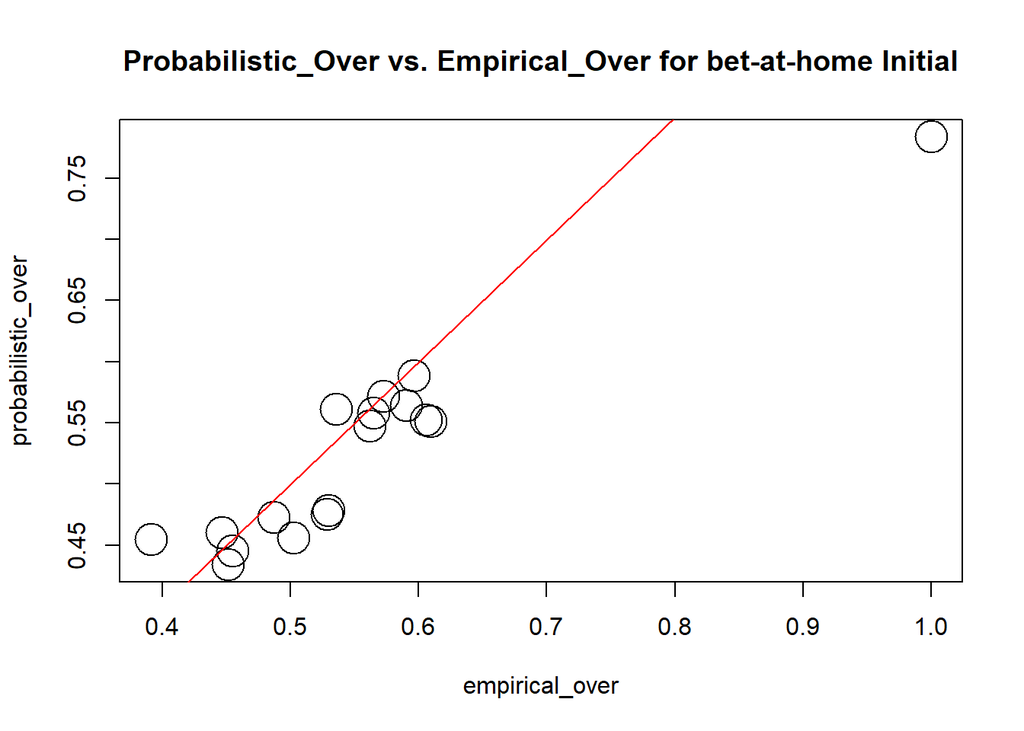

Figure 1: Initial Empirical and Probabilistic Value of Bookmaker bet-at-home

For a successful bookmaker, its implied “over” probability average in a bin should be very close or equal to the fraction of games finished over for the corresponding bin. For this plot, we can observe that majority of the points are around x=y line which means that these two types of values are very close. This means that odds of the bookmaker (probabilistic value) are close to actual output (empirical value) . As natural, there are fewer points which are close to 0 and 1 probability in other words, outliers. This means that the bookmaker gives meaningful odds.

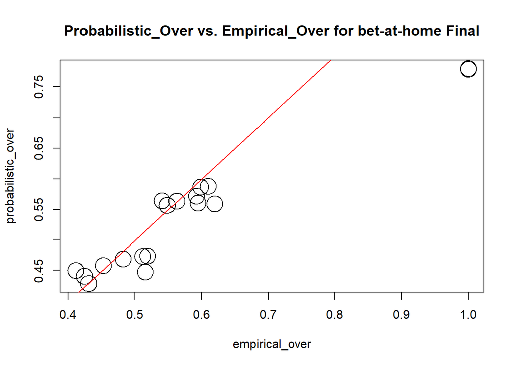

Figure 2: Final Empirical and Probabilistic Value of Bookmaker bet-at-home

Comparing this plot to previous plot, we can see that the number of points that are far from x=y line have decreased. For this plot, we can observe that majority of the points are around x=y line. This means that odds of the bookmaker (probabilistic value) are close to actual result (empirical value) . There is only one point that is close to the upper bound 1. We can say that odds of the bookmaker’s have improved.

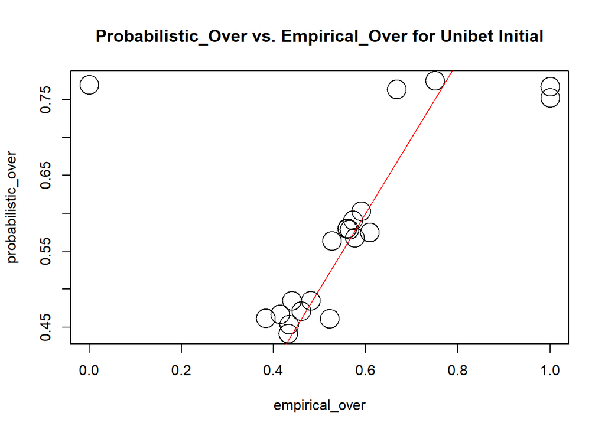

Figure 3: Initial Empirical and Probabilistic Value of Bookmaker Unibet

In this plot, we can say that majority of the points are around x=y line.For a successful bookmaker, its probabilistic value must be very close to empirical value. This means that these two types of probabilities are very close. We can conclude that odds of the bookmaker are consistent with the actual result. However there are some points that are too far from the line. This is not a situation we want to see.

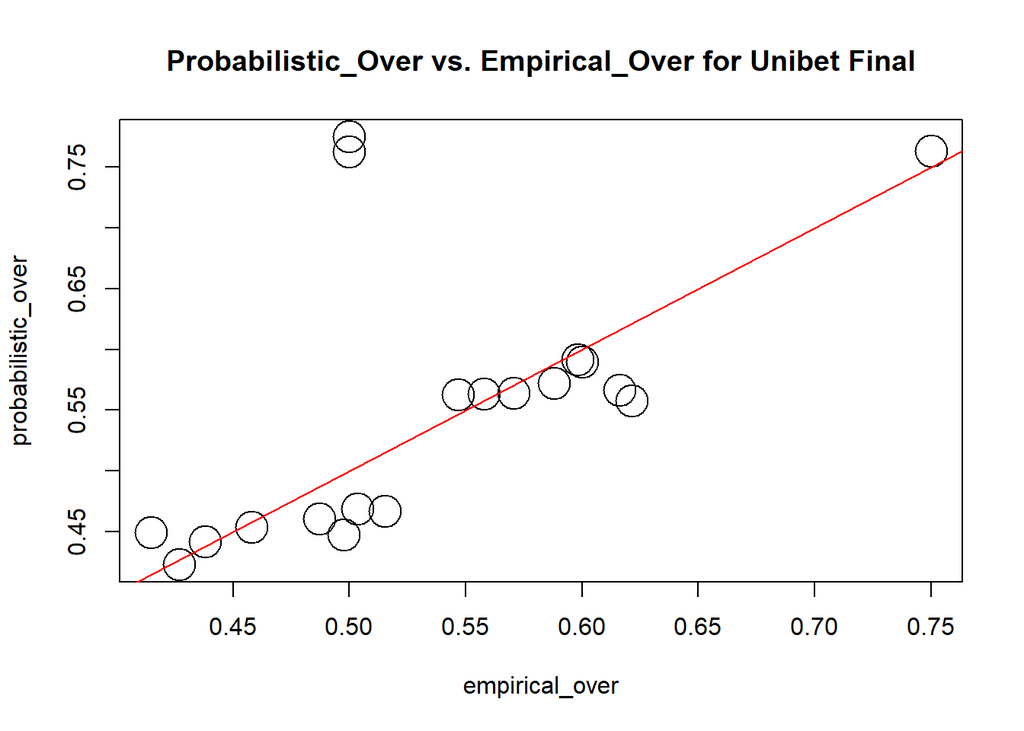

Figure 4: Final Empirical and Probabilistic Value of Bookmaker Unibet

In this plot we can observe that odds of the bookmaker have improved since there are fewer points away from x=y line. Since there are fewer amount of outliers in the plot, we can say that the bookmaker’s odds have become more reliable than the previous plot.

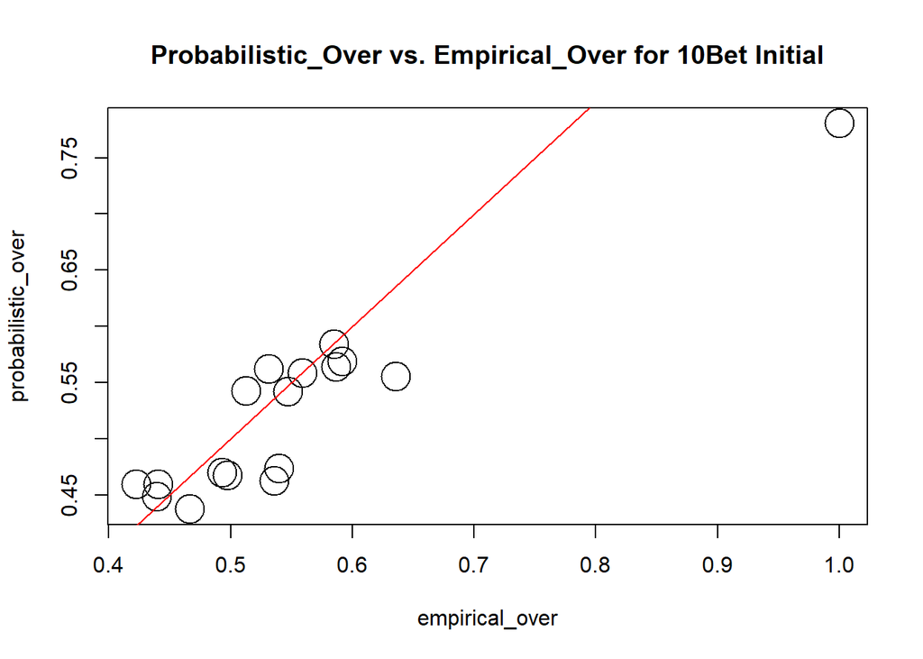

Figure 5: Initial Empirical and Probabilistic Value of Bookmaker 10Bet

For a successful bookmaker, its implied “over” probability average in a bin should be very close or equal to the fraction of games finished over for the corresponding bin. When we look at this plot, it is obvious that points are around x=y line with 0.4-0.6 probability range except one point which is close to upper bound 1. This means that odds are consistent with empirical value which makes the bookmaker successful.

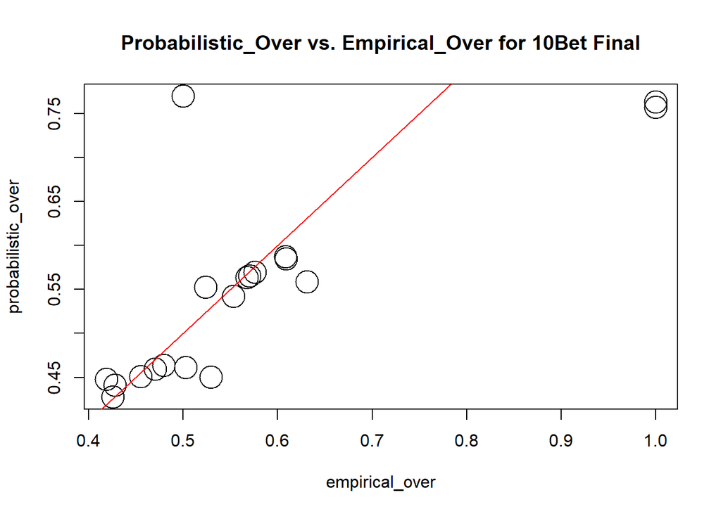

Figure 6: Final Empirical and Probabilistic Value of Bookmaker 10Bet

In this plot, the number of outliers have increased. Since there are more points away from the x=y line, we can infer that the bookmaker’s odds have become worse than its initial odds. There are two points close to the upper bound 1 which is something that we do not want to see in such a plot.

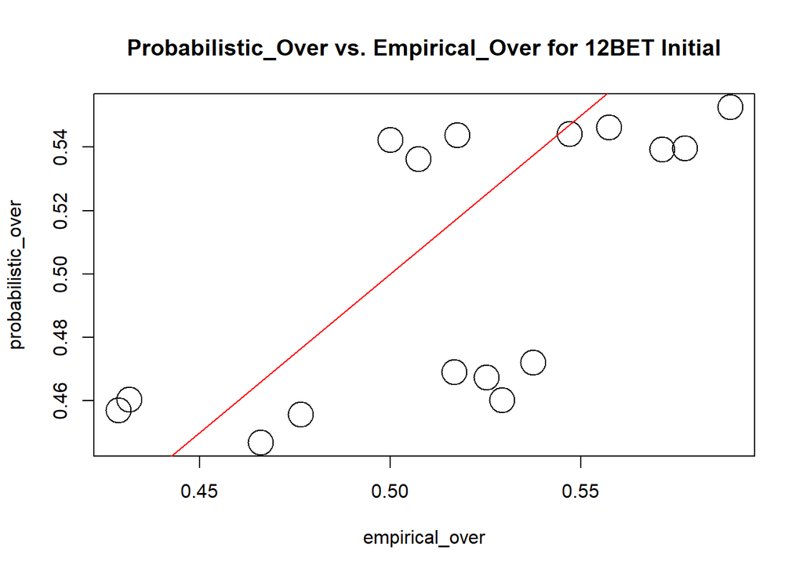

Figure 7: Initial Empirical and Probabilistic Value of Bookmaker 12BET

In this plot, we can observe that the points are not very close to x=y line. For this reason, we can say that the bookmaker’s odds are not consistent with the actual result. Because, its probabilistic value should be very close to the empirical value.

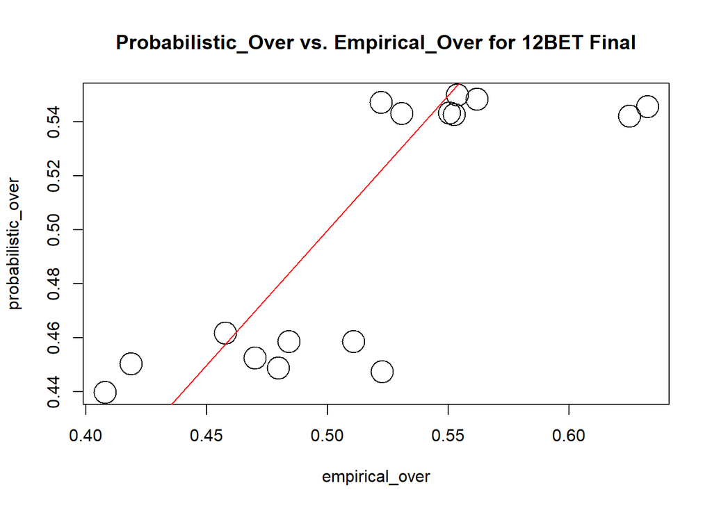

Figure 8: Final Empirical and Probabilistic Value of Bookmaker 12BET

In this plot, we can see that the points have come closer to x=y line, This means that odds of the bookmaker has improved. Probabilistic value of the odds is consistent with empirical value of the result. The bookmaker has become more reliable since the implied “over” probabilities are closer to the fraction of games.

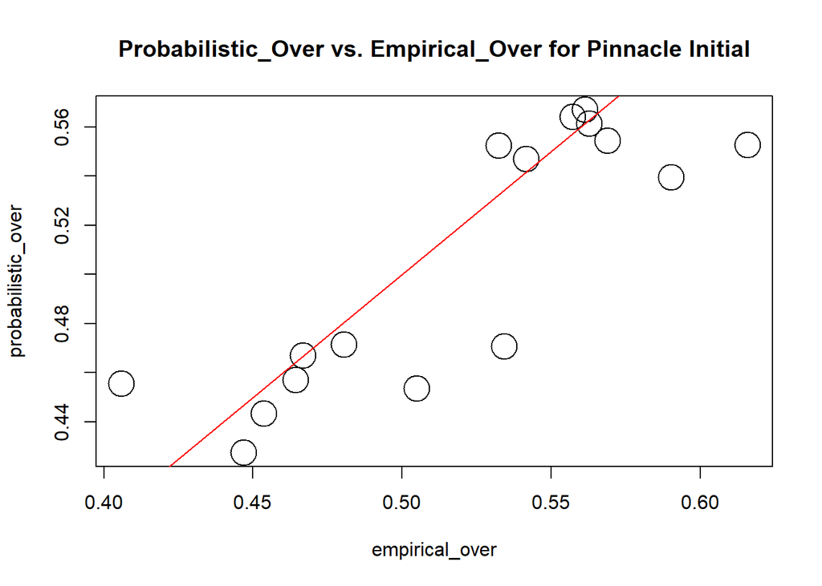

Figure 9: Initial Empirical and Probabilistic Value of Bookmaker Pinnacle

When we look at this plot, we can say that the majority of the points are around x=y line. However, there are some points that are far away from the line as well. Since there are obvious outliers in the plot, the bookmaker needs to improve its odds in order to become more realiable.

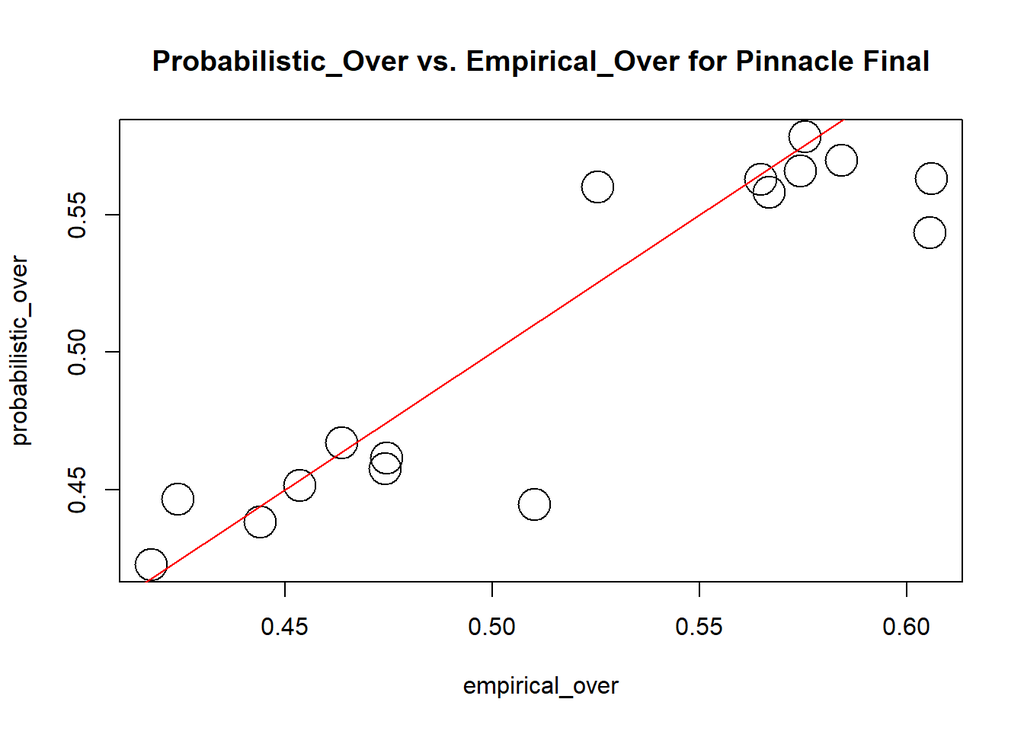

Figure 10: Final Empirical and Probabilistic Value of Bookmaker Pinnacle

In this plot, we can observe that there are less points away from x=y line. This means that, the bookmaker’s final odds are consistent with the actual results. Comparing to its initial plot, the bookmaker become more reliable which is a good thing to observe. Because a bookmaker should determine its odds as close as possible to actual match results in order to be successful.

**B)**

In order to investigate if bookmaker Pinnacle is consistently good at determinig “over” probabilities, I draw a plot which demonstrates the relationship between probabilistic values for each bin and corresponding empirical values over a given time period, in this case, years.

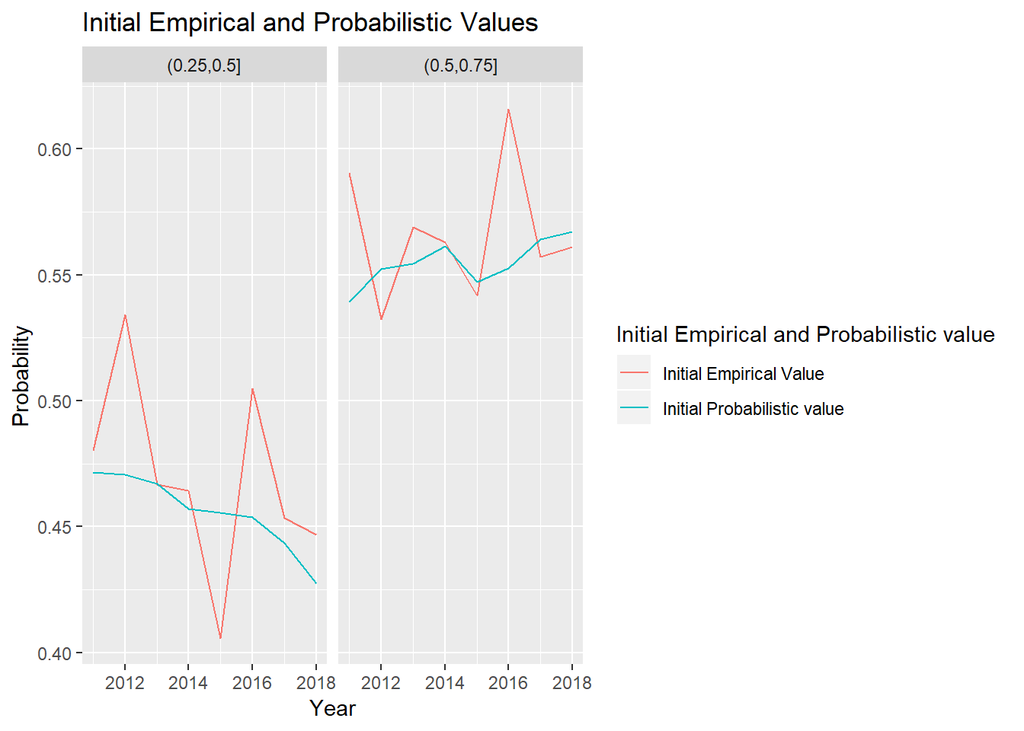

Figure 11: Initial Empirical and Probabilistic Value of Bookmaker Pinnacle

When we look at the bin “(0.25,0.5]”, we can compare initial empirical and probabilistic values for each year. For example, 2013 is the year that the bookmaker determined its odds consistent with the actual results. We can say this by looking at the lines which are very close to each other. In years of 2011,2014, 2017 and 2018, the bookmaker’s odds and actual results are not that close. Especially in year 2012,2015 and 2016 there are noticable differences between probabilistic and empirical values. We can infer that, in this year the bookmaker fails to determine its odds close to actual results.

When we look at the bin “(0.5,0.75]”, we can compare initial empirical and probabilistic values for each year as well.For example, 2014 and 2015 are the years that the bookmaker’s odds are close to actual results which makes the bookmaker successful. We can say this by looking at the lines of probabilistic and empirical values. 2012,2013, 2017 and 2018 are the years when the bookmaker was not bad at determining over probabilities. However, in 2011 and 2016, there are noticable differences between the lines. We can say that the bookmaker determined its odds unsuccessfully in that years.

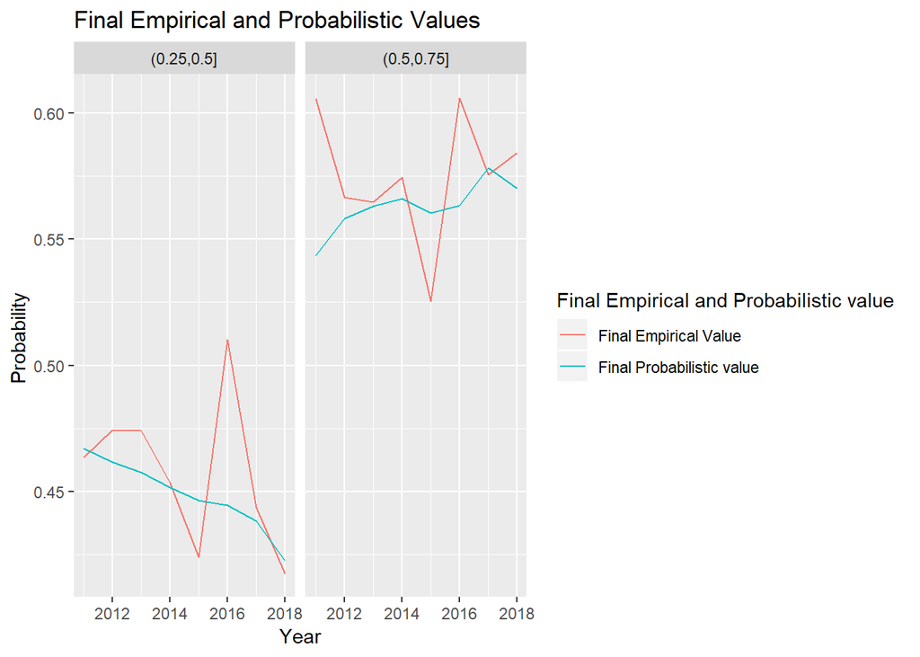

Figure 12: Final Empirical and Probabilistic Value of Bookmaker Pinnacle

When we look at the bin “(0.25,0.5]”, we can compare final empirical and probabilistic values for each year. For example, 2011,2014, 2017 and 2018 are the years that the bookmaker determined its odds consistent with the actual results. We can say this by looking at the lines which are very close to each other. In years of 2012,2013 and 2015, the bookmaker’s odds and actual results are not that close. Especially in year 2016, there is a noticable difference between probabilistic(implied over probability) and empirical(fraction of games) values. We can infer that, in this year the bookmaker fails to determine its odds consistent with actual results.

When we look at the bin “(0.5,0.75]”, we can compare final empirical and probabilistic values for each year as well.For example, 2013 and 2017 the bookmaker’s odds are close to actual results which makes the bookmaker successful. We can say this by looking at the lines of probabilistic and empirical values which are very close to each other. 2012,2014 and 2018 are the years when the bookmaker was not bad at determining over probabilities. However, in 2011, 2015 and 2016, there are noticable differences between the lines. We can say that the bookmaker determined its odds unsuccessfully in that years.

**Task-2**

For this task, we focused on the change of the odds over years. I chose bookmaker Pinnacle and bet type “1x2” to perform this task. I drew three different plots for home, away and draw win situations which show the relationship between initial and final odds. You can see the plots below.

**1- Home Win**

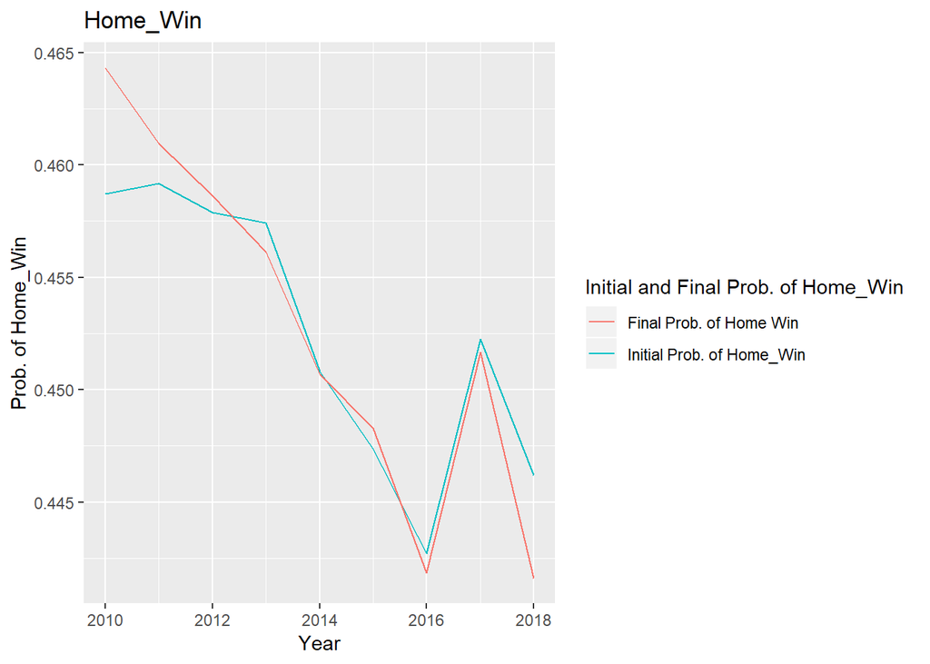

Figure 13: Initial and Final Probability of Home Win for Bookmaker Pinnacle

In this plot, we can see the relationship between initial and final probabilities. In 2010, there is an apparent difference between these two probabilities. However, these two lines became close over the years of2011 and 2012. Until 2018, the lines remained close to each other. In 2018, the difference between initial and final probabilities became noticable again.

**2- Away Win**

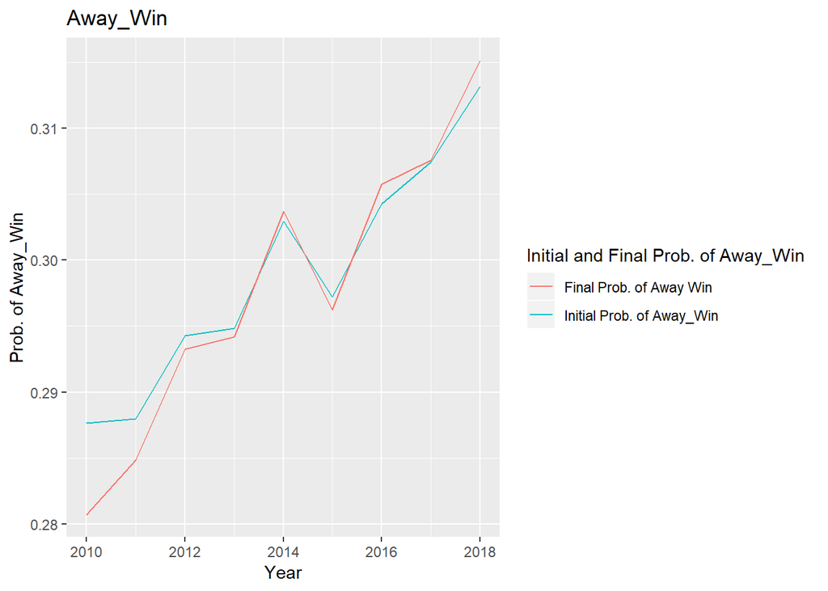

Figure 14: Initial and Final Probability of Away Win for Bookmaker Pinnacle

In this plot, there is a good relationship between initial and final probabilities. We can say that the bookmaker is consistent with its bets for most of the years. In 2010, the bookmaker changed its probabilities dramatically. In 2011 and 2012 initial and final probabilities became closer and closer. In the following years, the bookmaker determined its initial and final probabilities consistent with each other.

**3- Draw Win**

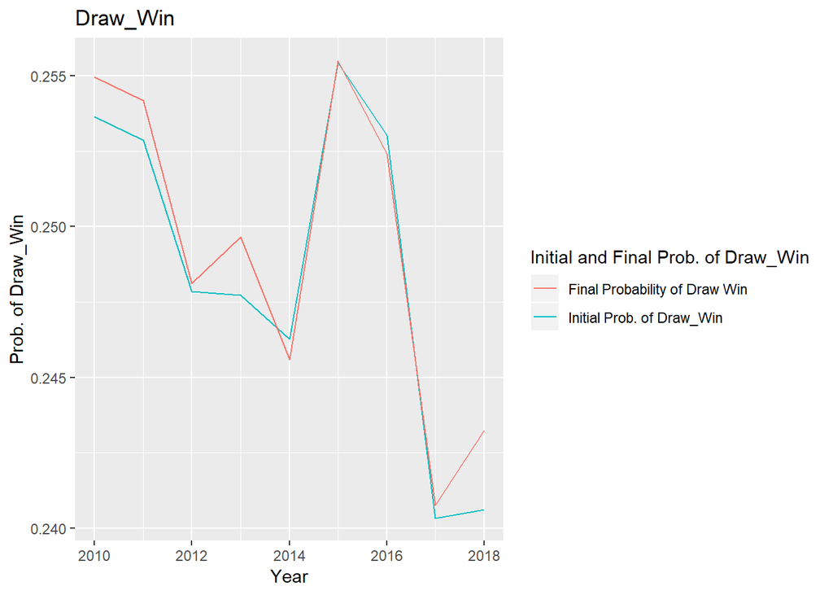

Figure 15: Initial and Final Probability of Draw Win for Bookmaker Pinnacle

In this plot, during most of the years the initial and final probabilities are close to each other.Especially in 2015, we can say that the bookmaker made almost no change in its bets. However, in year 2010, 2013 and 2018 there are noticable differences between these two probabilities.

**3-Appendix**

**Task 1**

**Codes for Option A**

require(data.table)

require(anytime)

`matches_file path` <- readRDS(“C:/Users/byuce/Downloads/df9b1196-e3cf-4cc7-9159-f236fe738215_matches.rds”) matches<-`matches_file path` odd_details_file_path <- readRDS(“C:/Users/byuce/Downloads/df9b1196-e3cf-4cc7-9159-f236fe738215_odd_details.rds”) odds<-odd_details_file_path

**i. Codes for “bet-at-home” initial odds**

betathome_over_under_initial=odds_ov_un_initial[bookmaker==‘bet-at-home’] betathome_wide_initial=dcast(betathome_over_under_initial,matchId~oddtype,value.var=‘start_odd’) matches[,Year:=year(match_time)] merged_matches_initial_betathome=merge(matches,betathome_wide_initial,by=‘matchId’) merged_matches_initial_betathome[,probOver:=1/over] merged_matches_initial_betathome[,probUnder:=1/under] merged_matches_initial_betathome[,totalProb:=probOver+probUnder] merged_matches_initial_betathome[,probOver:=probOver/totalProb] merged_matches_initial_betathome[,probUnder:=probUnder/totalProb] merged_matches_initial_betathome=merged_matches_initial_betathome[complete.cases(merged_matches_initial_betathome)] merged_matches_initial_betathome[,totalProb:=NULL] cutpoints=seq(0,1,0.1) merged_matches_initial_betathome[,odd_cut_over:=cut(probOver,cutpoints)] merged_matches_initial_betathome[,odd_cut_under:=cut(probUnder,cutpoints)] summary_table_initial_betathome=merged_matches_initial_betathome[,list(empirical_over=mean(IsOver),probabilistic_over=mean(probOver),.N),by=list(Year,odd_cut_over)] summary_table_initial_betathome=summary_table_initial_betathome[order(Year)] cutpoints=seq(0,1,0.2) merged_matches_initial_betathome[,odd_cut_over:=cut(probOver,cutpoints)] merged_matches_initial_betathome[,odd_cut_under:=cut(probUnder,cutpoints)] summary_table_initial_betathome=merged_matches_initial_betathome[,list(empirical_over=mean(IsOver),probabilistic_over=mean(probOver),.N),by=list(Year,odd_cut_over)] summary_table_initial_betathome=summary_table_initial_betathome[order(Year)] cutpoints=seq(0,1,0.25) merged_matches_initial_betathome[,odd_cut_over:=cut(probOver,cutpoints)] merged_matches_initial_betathome[,odd_cut_under:=cut(probUnder,cutpoints)] summary_table_initial_betathome=merged_matches_initial_betathome[,list(empirical_over=mean(IsOver),probabilistic_over=mean(probOver),.N),by=list(Year,odd_cut_over)] summary_table_initial_betathome=summary_table_initial_betathome[order(Year)] plot(summary_table_initial_betathome[,list(empirical_over,probabilistic_over)],cex=3, main=‘Compare probabilistic_over to empirical_over for bet-at-home initial’ ) abline(0,1,col=‘red’)

**ii. Codes for “bet-at-home” final odds**

betathome_over_under_final=odds_ov_un_final[bookmaker==‘bet-at-home’] betathome_wide_final=dcast(betathome_over_under_final,matchId~oddtype,value.var=‘final_odd’) merged_matches_final_betathome=merge(matches,betathome_wide_final,by=‘matchId’) merged_matches_final_betathome[,probOver:=1/over] merged_matches_final_betathome[,probUnder:=1/under] merged_matches_final_betathome[,totalProb:=probOver+probUnder] merged_matches_final_betathome[,probOver:=probOver/totalProb] merged_matches_final_betathome[,probUnder:=probUnder/totalProb] merged_matches_final_betathome=merged_matches_final_betathome[complete.cases(merged_matches_final_betathome)] merged_matches_final_betathome[,totalProb:=NULL] merged_matches_final_betathome[,odd_cut_over:=cut(probOver,cutpoints)] merged_matches_final_betathome[,odd_cut_under:=cut(probUnder,cutpoints)] summary_table_final_betathome=merged_matches_final_betathome[,list(empirical_over=mean(IsOver), probabilistic_over=mean(probOver),.N),by=list(Year,odd_cut_over)] summary_table_final_betathome=summary_table_final_betathome[order(Year)] plot(summary_table_final_betathome[,list(empirical_over,probabilistic_over)],cex=3, main=‘Compare probabilistic_over to empirical_over for bet-at-home final’ ) abline(0,1,col=‘red’)

**iii. Codes for unibet, 10bet, 12bet and Pinnacle**

Codes for these bookmakers are the same. I just changed the bookmaker name in the codes when it was necessary.

**Codes for Option B**

require(ggplot2)

**i. Codes for Initial Probabilities of Bookmaker Pinnacle**

cutpoints=seq(0,1,0.25) merged_matches_initial_pinnacle[,odd_cut_over:=cut(probOver,cutpoints)] merged_matches_initial_pinnacle[,odd_cut_under:=cut(probUnder,cutpoints)] summary_table_initial_pinnacle=merged_matches_initial_pinnacle[,list(empirical_over=mean(IsOver),probabilistic_over=mean(probOver),.N),by=list(Year,odd_cut_over)] summary_table_initial_pinnacle=summary_table_initial_pinnacle[order(Year)]

ggplot(summary_table_initial_pinnacle,aes(x=Year))+geom_line(data=summary_table_initial_pinnacle,aes(y=empirical_over, color=“Initial Empirical Value”))+ geom_line(data=summary_table_initial_pinnacle,aes(y=probabilistic_over, color=“Initial Probabilistic value”)) + labs(color=“Initial Empirical and Probabilistic value”) + ylab(“Probability”) + ggtitle(“Initial Empirical and Probabilistic Values”) + facet_wrap(~ odd_cut_over)

**ii. Codes for Final Probabilities of Bookmaker Pinnacle**

cutpoints=seq(0,1,0.25)

merged_matches_final_pinnacle[,odd_cut_under:=cut(probUnder,cutpoints)] summary_table_final_pinnacle=merged_matches_final_pinnacle[,list(empirical_over=mean(IsOver),probabilistic_over=mean(probOver),.N),by=list(Year,odd_cut_over)] summary_table_final_pinnacle=summary_table_final_pinnacle[order(Year)]

ggplot(summary_table_final_pinnacle,aes(x=Year))+geom_line(data=summary_table_final_pinnacle,aes(y=empirical_over, color=“Final Empirical Value”))+ geom_line(data=summary_table_final_pinnacle,aes(y=probabilistic_over, color=“Final Probabilistic value”)) + labs(color=“Final Empirical and Probabilistic value”) + ylab(“Probability”) + ggtitle(“Final Empirical and Probabilistic Values”) + facet_wrap(~ odd_cut_over)

**Task 2**

**i. Home Win**

ggplot(summary_table_merged_matches_initial_Pinnacle_1_2,aes(x=Year,y=prob_1))+geom_line(data=summary_table_merged_matches_initial_Pinnacle_1_2,aes(color=“Initial Prob. of Home_Win”))+ geom_line(data=summary_table_merged_matches_final_Pinnacle_1_2,aes(color=“Final Prob. of Home Win”)) + labs(color=“Initial and Final Prob. of Home_Win”) + ylab(“Prob. of Home_Win”) + ggtitle(“Home_Win”)

**ii. Away Win**

ggplot(summary_table_merged_matches_initial_Pinnacle_1_2,aes(x=Year,y=prob_2))+geom_line(data=summary_table_merged_matches_initial_Pinnacle_1_2,aes(color=“Initial Prob. of Away_Win”))+ geom_line(data=summary_table_merged_matches_final_Pinnacle_1_2,aes(color=“Final Prob. of Away Win”)) + labs(color=“Initial and Final Prob. of Away_Win”) + ylab(“Prob. of Away_Win”) + ggtitle(“Away_Win”)

**iii. Draw Win**

ggplot(summary_table_merged_matches_initial_Pinnacle_1_2,aes(x=Year,y=prob_X))+geom_line(data=summary_table_merged_matches_initial_Pinnacle_1_2,aes(color=“Initial Prob. of Draw_Win”))+ geom_line(data=summary_table_merged_matches_final_Pinnacle_1_2,aes(color=“Final Probability of Draw Win”)) + labs(color=“Initial and Final Prob. of Draw_Win”) + ylab(“Prob. of Draw_Win”) + ggtitle(“Draw_Win”)